# Capstone Project

## Image classifier for the SVHN dataset

### Instructions

In this notebook, you will create a neural network that classifies real-world images digits. You will use concepts from throughout this course in building, training, testing, validating and saving your Tensorflow classifier model.

This project is peer-assessed. Within this notebook you will find instructions in each section for how to complete the project. Pay close attention to the instructions as the peer review will be carried out according to a grading rubric that checks key parts of the project instructions. Feel free to add extra cells into the notebook as required.

### How to submit

When you have completed the Capstone project notebook, you will submit a pdf of the notebook for peer review. First ensure that the notebook has been fully executed from beginning to end, and all of the cell outputs are visible. This is important, as the grading rubric depends on the reviewer being able to view the outputs of your notebook. Save the notebook as a pdf (File -> Download as -> PDF via LaTeX). You should then submit this pdf for review.

### Let's get started!

We'll start by running some imports, and loading the dataset. For this project you are free to make further imports throughout the notebook as you wish.

```python
import tensorflow as tf
from scipy.io import loadmat


#from tensorflow.keras.preprocessing import image
import matplotlib.pyplot as plt
import numpy as np
import pandas as pd


# Additional libraries
import random
from tensorflow.keras.models import Sequential
from tensorflow.keras.layers import Dense, Flatten, Softmax, Conv2D, MaxPooling2D
from tensorflow.keras.callbacks import ModelCheckpoint, EarlyStopping
from tensorflow.keras.layers import Dropout
from tensorflow.keras import regularizers
```

[figure not shown]

For the capstone project, you will use the [SVHN dataset](http://ufldl.stanford.edu/housenumbers/). This is an image dataset of over 600,000 digit images in all, and is a harder dataset than MNIST as the numbers appear in the context of natural scene images. SVHN is obtained from house numbers in Google Street View images.

- Y. Netzer, T. Wang, A. Coates, A. Bissacco, B. Wu and A. Y. Ng. "Reading Digits in Natural Images with Unsupervised Feature Learning". NIPS Workshop on Deep Learning and Unsupervised Feature Learning, 2011.

Your goal is to develop an end-to-end workflow for building, training, validating, evaluating and saving a neural network that classifies a real-world image into one of ten classes.

```python
# Run this cell to load the dataset

train = loadmat('data/train_32x32.mat')
test = loadmat('data/test_32x32.mat')
```

Both `train` and `test` are dictionaries with keys `X` and `y` for the input images and labels respectively.

## 1. Inspect and preprocess the dataset

- Extract the training and testing images and labels separately from the train and test dictionaries loaded for you.
- Select a random sample of images and corresponding labels from the dataset (at least 10), and display them in a figure.
- Convert the training and test images to grayscale by taking the average across all colour channels for each pixel. *Hint: retain the channel dimension, which will now have size 1.*
- Select a random sample of the grayscale images and corresponding labels from the dataset (at least 10), and display them in a figure.

```python
# Obtain the images and labels and rescale
train_images = train['X'] /255
test_images = test['X'] /255
train_labels = train['y']
test_labels = test['y']

# Obtain the training set shape
print('The training set shape is {}'.format(train_images.shape))
```

```
The training set shape is (32, 32, 3, 73257)
```

```python
#Generate 10 random numbers to index the training set
randomlist = random.sample(range(0, train_images.shape[3]), 10)
print(randomlist)
```

```
[32844, 10126, 42563, 21753, 72833, 61907, 57923, 20697, 69994, 29848]
```

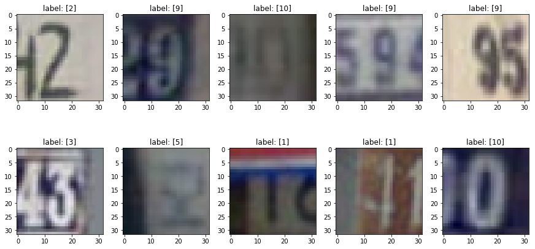

```python
#Display the images and labels

f, ax = plt.subplots(2,5,figsize=(12,6), constrained_layout=True)
for i in range (2):
    for j in range (5):
        x=randomlist[(i*5)+j]
        img = train_images[:,:,:,x]
        ax[i,j].imshow(img)
        ax[i,j].set_title(f"label: {train_labels[x]}")
plt.show()
```

```python
#Take the average across the color channels
train_img_gray = np.mean(train_images, axis=2)
test_img_gray = np.mean(test_images, axis=2)
```

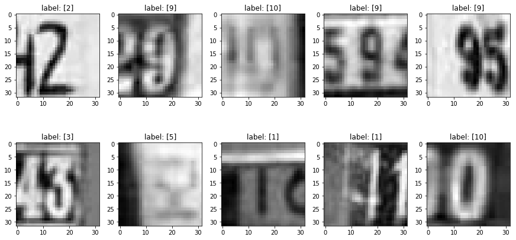

```python
f, ax = plt.subplots(2,5,figsize=(12,6), constrained_layout=True)
for i in range (2):
    for j in range (5):
        x=randomlist[(i*5)+j]
        img = train_img_gray[:,:,x]
        ax[i,j].imshow(img,cmap='gray')
        ax[i,j].set_title(f"label: {train_labels[x]}")
plt.show()
```

```python
# Add a dummy channel dimension
train_img_gray = train_img_gray[..., np.newaxis]
test_img_gray = test_img_gray[..., np.newaxis]
```

```python
#Note that the axis are not in the prefered sequence
train_img_gray.shape
```

```
(32, 32, 73257, 1)
```

```python
train_img_gray = np.swapaxes(train_img_gray,0,2)
train_img_gray = np.swapaxes(train_img_gray,1,2)

test_img_gray = np.swapaxes(test_img_gray,0,2)
test_img_gray = np.swapaxes(test_img_gray,1,2)


train_img_gray.shape
```

```
(73257, 32, 32, 1)
```

```python
#Noting that 0 has been assigned a label 10 we need to recodify
train_labels = np.where(train_labels == 10, 0, train_labels)
test_labels = np.where(test_labels == 10, 0, test_labels)
```

## 2. MLP neural network classifier

- Build an MLP classifier model using the Sequential API. Your model should use only Flatten and Dense layers, with the final layer having a 10-way softmax output.
- You should design and build the model yourself. Feel free to experiment with different MLP architectures. *Hint: to achieve a reasonable accuracy you won't need to use more than 4 or 5 layers.*
- Print out the model summary (using the summary() method)
- Compile and train the model (we recommend a maximum of 30 epochs), making use of both training and validation sets during the training run.
- Your model should track at least one appropriate metric, and use at least two callbacks during training, one of which should be a ModelCheckpoint callback.
- As a guide, you should aim to achieve a final categorical cross entropy training loss of less than 1.0 (the validation loss might be higher).
- Plot the learning curves for loss vs epoch and accuracy vs epoch for both training and validation sets.
- Compute and display the loss and accuracy of the trained model on the test set.

```python
#Define the input shape
input_shape = train_img_gray[1,:,:,:].shape
print('Input shape:   {}'.format(input_shape))
```

```
Input shape:   (32, 32, 1)
```

```python
#Create a function to generate a model using the Sequential API
def get_model():
    return(Sequential([
        Flatten(input_shape=input_shape),
        Dense(256, activation='relu'),
        Dense(256, activation='relu'),
        Dense(256, activation='relu'),
        Dense(10, activation='softmax')
    ]))

#Call the get_model() function
model = get_model()

#Display a model summary
model.summary()
```

```
Model: "sequential"
_________________________________________________________________
Layer (type)                 Output Shape              Param #
=================================================================
flatten (Flatten)            (None, 1024)              0
_________________________________________________________________
dense (Dense)                (None, 256)               262400
_________________________________________________________________
dense_1 (Dense)              (None, 256)               65792
_________________________________________________________________
dense_2 (Dense)              (None, 256)               65792
_________________________________________________________________
dense_3 (Dense)              (None, 10)                2570
=================================================================
Total params: 396,554
Trainable params: 396,554
Non-trainable params: 0
_________________________________________________________________
```

```python
def compile_model(model):
    """
    This function takes in the model and compiles it with an Adam optimiser,
    cross-entropy loss function and accuracy metric.
    """
    model.compile(optimizer='adam',
              loss = 'sparse_categorical_crossentropy',
              metrics=['accuracy'])

#build the model
compile_model(model)
```

```python
def get_early_stopping():
    """
    This function returns an EarlyStopping callback
    """
    return(tf.keras.callbacks.EarlyStopping(monitor='val_accuracy', patience=3))


def get_checkpoint_best(path):
    """
    This function returns the model_weights at the end of an epoch when val_accuracy improves

    """
    checkpoint_path = path
    return(ModelCheckpoint(filepath=checkpoint_path,
                           frequency='epoch',
                           save_weights_only=True,
                           monitor='val_accuracy',
                           save_best_only=True,
                           verbose=1)
          )

checkpoint_best = get_checkpoint_best('model_checkpoints_best/checkpoint')
early_stopping = get_early_stopping()
```

```python
# Fit the model
history = model.fit(train_img_gray,
                    train_labels,
                    epochs=30,
                    validation_data=(test_img_gray, test_labels),
                    batch_size=256,
                    callbacks=[checkpoint_best, early_stopping],
                    verbose=1)
```

```
Train on 73257 samples, validate on 26032 samples
Epoch 00001: val_accuracy improved from -inf to 0.52543, saving model to model_checkpoints_best/checkpoint
Epoch 00002: val_accuracy improved from 0.52543 to 0.59723, saving model to model_checkpoints_best/checkpoint
Epoch 00003: val_accuracy improved from 0.59723 to 0.66764, saving model to model_checkpoints_best/checkpoint
Epoch 00004: val_accuracy improved from 0.66764 to 0.68704, saving model to model_checkpoints_best/checkpoint
Epoch 00005: val_accuracy improved from 0.68704 to 0.70698, saving model to model_checkpoints_best/checkpoint
Epoch 00006: val_accuracy did not improve from 0.70698
Epoch 00007: val_accuracy improved from 0.70698 to 0.71047, saving model to model_checkpoints_best/checkpoint
Epoch 00008: val_accuracy improved from 0.71047 to 0.72614, saving model to model_checkpoints_best/checkpoint
Epoch 00009: val_accuracy improved from 0.72614 to 0.73805, saving model to model_checkpoints_best/checkpoint
Epoch 00010: val_accuracy improved from 0.73805 to 0.74927, saving model to model_checkpoints_best/checkpoint
Epoch 00011: val_accuracy improved from 0.74927 to 0.76798, saving model to model_checkpoints_best/checkpoint
Epoch 00012: val_accuracy improved from 0.76798 to 0.76898, saving model to model_checkpoints_best/checkpoint
Epoch 00013: val_accuracy did not improve from 0.76898
Epoch 00014: val_accuracy improved from 0.76898 to 0.77336, saving model to model_checkpoints_best/checkpoint
Epoch 00015: val_accuracy improved from 0.77336 to 0.77712, saving model to model_checkpoints_best/checkpoint
Epoch 00016: val_accuracy did not improve from 0.77712
Epoch 00017: val_accuracy did not improve from 0.77712
Epoch 00018: val_accuracy improved from 0.77712 to 0.78327, saving model to model_checkpoints_best/checkpoint
Epoch 00019: val_accuracy improved from 0.78327 to 0.79771, saving model to model_checkpoints_best/checkpoint
Epoch 00020: val_accuracy did not improve from 0.79771
Epoch 00021: val_accuracy did not improve from 0.79771
Epoch 00022: val_accuracy did not improve from 0.79771
```

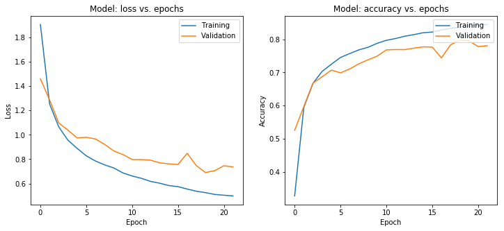

```python
#Plot the learning curves for loss vs epoch and accuracy vs epoch for both training and validation sets.
import matplotlib.pyplot as plt

fig = plt.figure(figsize=(12, 5))

fig.add_subplot(121)

plt.plot(history.history['loss'])
plt.plot(history.history['val_loss'])
plt.title('Model: loss vs. epochs')
plt.ylabel('Loss')
plt.xlabel('Epoch')
plt.legend(['Training', 'Validation'], loc='upper right')

fig.add_subplot(122)

plt.plot(history.history['accuracy'])
plt.plot(history.history['val_accuracy'])
plt.title('Model: accuracy vs. epochs')
plt.ylabel('Accuracy')
plt.xlabel('Epoch')
plt.legend(['Training', 'Validation'], loc='upper right')

plt.show()
```

```python
# Compute and display the loss and accuracy of the trained model on the test set
test_loss, test_acc = model.evaluate(x=test_img_gray, y=test_labels, verbose=0)
print('accuracy: {acc:0.3f}'.format(acc=test_acc))
print('loss: {loss:0.3f}'.format(loss=test_loss))
```

```
accuracy: 0.781
loss: 0.737
```

## 3. CNN neural network classifier

- Build a CNN classifier model using the Sequential API. Your model should use the Conv2D, MaxPool2D, BatchNormalization, Flatten, Dense and Dropout layers. The final layer should again have a 10-way softmax output.
- You should design and build the model yourself. Feel free to experiment with different CNN architectures. *Hint: to achieve a reasonable accuracy you won't need to use more than 2 or 3 convolutional layers and 2 fully connected layers.)*
- The CNN model should use fewer trainable parameters than your MLP model.
- Compile and train the model (we recommend a maximum of 30 epochs), making use of both training and validation sets during the training run.
- Your model should track at least one appropriate metric, and use at least two callbacks during training, one of which should be a ModelCheckpoint callback.
- You should aim to beat the MLP model performance with fewer parameters!
- Plot the learning curves for loss vs epoch and accuracy vs epoch for both training and validation sets.
- Compute and display the loss and accuracy of the trained model on the test set.

```python
#Create a function to generate a CNN classifier model using the Sequential API
def get_CNN_model(wd, rate):
    return(Sequential([
        Conv2D(filters=16, input_shape=input_shape, kernel_size=(3, 3),
               padding ='SAME', activation='relu', name='conv_1'),


        Conv2D(filters=8, kernel_size=(3, 3),
               padding ='SAME', activation='relu', name='conv_2'),

        MaxPooling2D(pool_size=(2, 2), name='pool_1'),

        Flatten(name='flatten'),

        Dense(units=32, activation='relu', kernel_regularizer=regularizers.l2(wd), name='dense_1'),

        Dense(units=10, activation='softmax', name='dense_2')
    ]))
```

```python
#Call the get_CNN_model() function
CNN_model = get_CNN_model(1e-5,0.3)

#Display a model summary
CNN_model.summary()
```

```
Model: "sequential_1"
_________________________________________________________________
Layer (type)                 Output Shape              Param #
=================================================================
conv_1 (Conv2D)              (None, 32, 32, 16)        160
_________________________________________________________________
conv_2 (Conv2D)              (None, 32, 32, 8)         1160
_________________________________________________________________
pool_1 (MaxPooling2D)        (None, 16, 16, 8)         0
_________________________________________________________________
flatten (Flatten)            (None, 2048)              0
_________________________________________________________________
dense_1 (Dense)              (None, 32)                65568
_________________________________________________________________
dense_2 (Dense)              (None, 10)                330
=================================================================
Total params: 67,218
Trainable params: 67,218
Non-trainable params: 0
_________________________________________________________________
```

```python
#build the model
compile_model(CNN_model)

#define the save model weights callback
checkpoint_best_CNN = get_checkpoint_best('model_checkpoints_best_CNN/checkpoint')

# Fit the model
CNN_history = CNN_model.fit(train_img_gray,
                    train_labels,
                    epochs=30,
                    validation_data=(test_img_gray, test_labels),
                    batch_size=256,
                    callbacks=[checkpoint_best_CNN, early_stopping],
                    verbose=1)
```

```
Train on 73257 samples, validate on 26032 samples
Epoch 00001: val_accuracy improved from -inf to 0.64947, saving model to model_checkpoints_best_CNN/checkpoint
Epoch 00002: val_accuracy improved from 0.64947 to 0.74800, saving model to model_checkpoints_best_CNN/checkpoint
Epoch 00003: val_accuracy improved from 0.74800 to 0.78607, saving model to model_checkpoints_best_CNN/checkpoint
Epoch 00004: val_accuracy improved from 0.78607 to 0.79944, saving model to model_checkpoints_best_CNN/checkpoint
Epoch 00005: val_accuracy improved from 0.79944 to 0.81223, saving model to model_checkpoints_best_CNN/checkpoint
Epoch 00006: val_accuracy improved from 0.81223 to 0.82425, saving model to model_checkpoints_best_CNN/checkpoint
Epoch 00007: val_accuracy improved from 0.82425 to 0.82806, saving model to model_checkpoints_best_CNN/checkpoint
Epoch 00008: val_accuracy improved from 0.82806 to 0.83059, saving model to model_checkpoints_best_CNN/checkpoint
Epoch 00009: val_accuracy did not improve from 0.83059
Epoch 00010: val_accuracy did not improve from 0.83059
Epoch 00011: val_accuracy improved from 0.83059 to 0.83728, saving model to model_checkpoints_best_CNN/checkpoint
Epoch 00012: val_accuracy improved from 0.83728 to 0.84031, saving model to model_checkpoints_best_CNN/checkpoint
Epoch 00013: val_accuracy did not improve from 0.84031
Epoch 00014: val_accuracy did not improve from 0.84031
Epoch 00015: val_accuracy did not improve from 0.84031
```

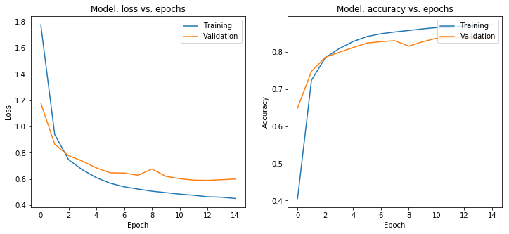

```python
#Plot the learning curves for loss vs epoch and accuracy vs epoch for both training and validation sets.

import matplotlib.pyplot as plt


fig = plt.figure(figsize=(12, 5))

fig.add_subplot(121)

plt.plot(CNN_history.history['loss'])
plt.plot(CNN_history.history['val_loss'])
plt.title('Model: loss vs. epochs')
plt.ylabel('Loss')
plt.xlabel('Epoch')
plt.legend(['Training', 'Validation'], loc='upper right')

fig.add_subplot(122)

plt.plot(CNN_history.history['accuracy'])
plt.plot(CNN_history.history['val_accuracy'])
plt.title('Model: accuracy vs. epochs')
plt.ylabel('Accuracy')
plt.xlabel('Epoch')
plt.legend(['Training', 'Validation'], loc='upper right')

plt.show()
```

```python
# Calculate the accuracy and loss of the CNN_model on the test set
test_loss, test_acc = CNN_model.evaluate(x=test_img_gray, y=test_labels, verbose=0)
print('accuracy: {acc:0.3f}'.format(acc=test_acc))
print('loss: {loss:0.3f}'.format(loss=test_loss))
```

```
accuracy: 0.839
loss: 0.600
```

## 4. Get model predictions

- Load the best weights for the MLP and CNN models that you saved during the training run.
- Randomly select 5 images and corresponding labels from the test set and display the images with their labels.
- Alongside the image and label, show each model’s predictive distribution as a bar chart, and the final model prediction given by the label with maximum probability.

```python
# View the available checkpoints
! ls -lh model_checkpoints_best
```

```
total 4.6M
-rw-r--r-- 1 jovyan users   77 Jan 14 11:35 checkpoint
-rw-r--r-- 1 jovyan users 4.6M Jan 14 11:35 checkpoint.data-00000-of-00001
-rw-r--r-- 1 jovyan users 2.1K Jan 14 11:35 checkpoint.index
```

```python
# Load weights -- accuracy is the same as the trained model
model.load_weights('model_checkpoints_best/checkpoint')
CNN_model.load_weights('model_checkpoints_best_CNN/checkpoint')
```

```
<tensorflow.python.training.tracking.util.CheckpointLoadStatus at 0x7fcc084b7ba8>
```

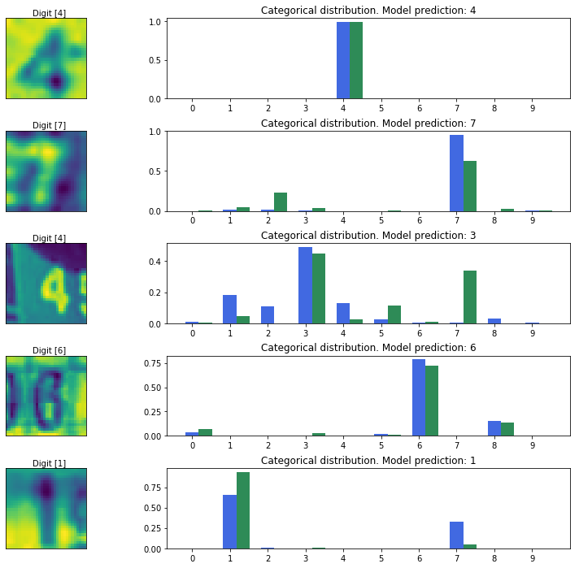

```python
# Run this cell to get model predictions on randomly selected test images

num_test_images = test_img_gray.shape[0]

random_inx = np.random.choice(num_test_images, 5)

random_test_images = test_img_gray[random_inx, ...]
random_test_labels = test_labels[random_inx, ...]

predictions = model.predict(random_test_images)
CNN_predictions = CNN_model.predict(random_test_images)

ind = np.arange(len(predictions[0]))  # the x locations for the groups
width = 0.35

fig, axes = plt.subplots(5, 2, figsize=(16, 12))
fig.subplots_adjust(hspace=0.4, wspace=-0.2)

for i, (CNN_prediction, prediction, image, label) in enumerate(zip(CNN_predictions, predictions, random_test_images, random_test_labels)):
    axes[i, 0].imshow(np.squeeze(image))
    axes[i, 0].get_xaxis().set_visible(False)
    axes[i, 0].get_yaxis().set_visible(False)
    axes[i, 0].text(10., -1.5, f'Digit {label}')

    axes[i, 1].bar(ind, prediction,width, color='royalblue', label='MLP')
    axes[i, 1].bar(ind+width, CNN_prediction,width, color='seagreen',label='CNN')

    axes[i, 1].set_xticks(ind)
    axes[i, 1].set_title(f"Categorical distribution. Model prediction: {np.argmax(prediction)}")


plt.show()
```